# Ventas Apple

Sara Bengoechea Rodriguez

11/16/2020

## Introducción

El presente informe tiene como objetivo predecir las ventas de Apple para el año 2017 y 2018, a partir de los datos disponibles desde el segundo trimestre de 2008 hasta el cuarto trimestre de 2016 mediante un modelo ETS y un modelo ARIMA.

Para comenzar, se deben cargar las librerías necesarias e importar la base de datos IngresosApple.csv de Bloomberg. Para poder trabajar con ella y generar los datos por trimestre, se deben transformar a XTS y posteriormente a zoo para poder realizar forecasting sobre ella.

Con la información disponible, los ingresos por trimestre se representarían de la siguiente manera:

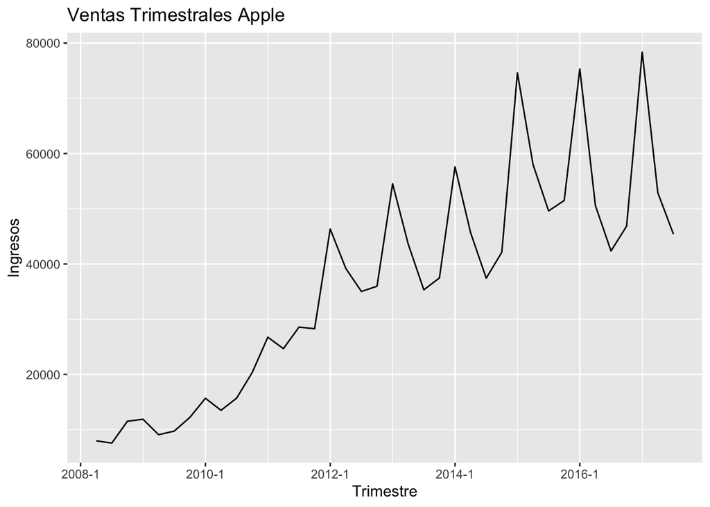

## MODELO ETS

Antes de elaborar el modelo ETS debemos eliminar del training set las observaciones pertenecientes a los trimestres de 2017, y a continuación, seleccionamos de manera automática el modelo ETS mediante la función ets().

El siguiente summary muestra los aspectos más relevantes del mejor modelo ETS escogido de manera automática.

```
## ETS(M,A,M)
##
## Call:
##  ets(y = o_Sales)
##
##   Smoothing parameters:
##     alpha = 0.493
##     beta  = 0.493
##     gamma = 0.507
##
##   Initial states:
##     l = 7125.3462
##     b = 1485.7975
##     s = 1.1511 1.1163 0.8322 0.9004
##
##   sigma:  0.1222
##
##      AIC     AICc      BIC
## 703.9538 711.1538 717.9519
##
## Training set error measures:
##                   ME     RMSE      MAE       MPE     MAPE      MASE      ACF1
## Training set -41.934 4120.155 2883.262 -0.297759 8.677434 0.4160202 0.1438481
```

El siguiente paso sería realizar predicciones con la función forecast() para el modelo seleccionado. Debajo se muestra el summary y una tabla con los intervalos de predicción. La manera de interpretarlo sería la siguiente: Hay un 80% de probabilidades de que las ventas de Apple para el primer cuatrimestre del 2017 estén entre 58568.387(lower bound) y 80311.27(higher bound); y de igual interpretación para una probabilidad del 95% con sus valores correspondinetes de la tabla.

```
##
## Forecast method: ETS(M,A,M)
##
## Model Information:
## ETS(M,A,M)
##
## Call:
##  ets(y = o_Sales)
##
##   Smoothing parameters:
##     alpha = 0.493
##     beta  = 0.493
##     gamma = 0.507
##
##   Initial states:
##     l = 7125.3462
##     b = 1485.7975
##     s = 1.1511 1.1163 0.8322 0.9004
##
##   sigma:  0.1222
##
##      AIC     AICc      BIC
## 703.9538 711.1538 717.9519
##
## Error measures:
##                   ME     RMSE      MAE       MPE     MAPE      MASE      ACF1
## Training set -41.934 4120.155 2883.262 -0.297759 8.677434 0.4160202 0.1438481
##
## Forecasts:
##         Point Forecast     Lo 80     Hi 80      Lo 95     Hi 95
## 2017 Q1       69439.83 58568.387  80311.27  52813.394  86066.26
## 2017 Q2       53347.98 41773.016  64922.95  35645.598  71050.37
## 2017 Q3       48972.04 33884.613  64059.47  25897.811  72046.27
## 2017 Q4       54176.09 31475.035  76877.14  19457.824  88894.35
## 2018 Q1       80540.07 32680.293 128399.85   7344.857 153735.28
## 2018 Q2       61619.03 17211.212 106026.85  -6296.866 129534.93
## 2018 Q3       56344.41  7869.773 104819.05 -17791.151 130479.97
## 2018 Q4       62103.80  -718.363 124925.97 -33974.410 158182.02
```

La predicción del modelo ETS se puede representar mediante en el gráfico inferior.

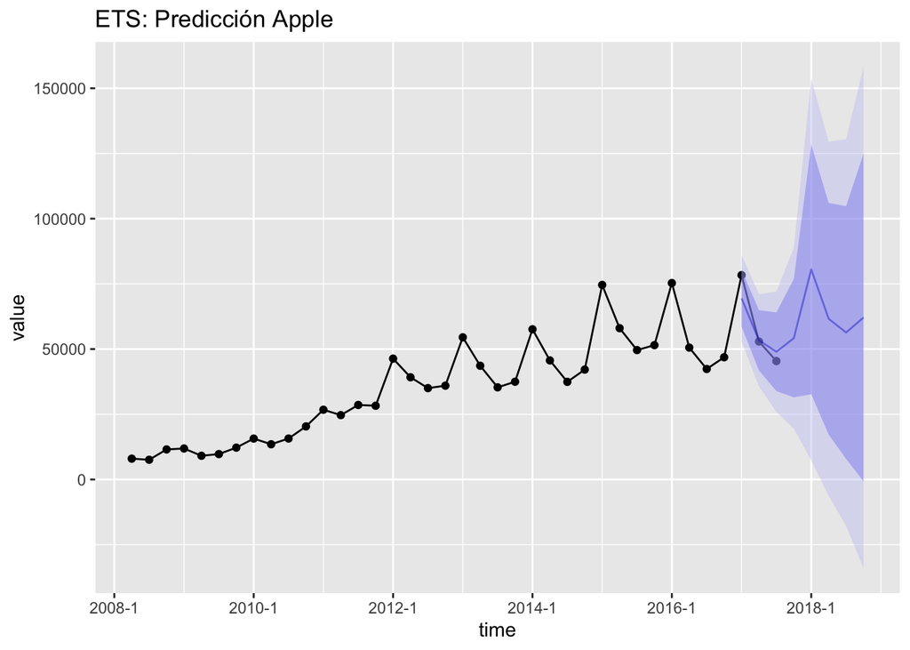

Para poder comparar entre la estimación y las ventas reales podemos observar la siguiente matriz:

```
##          [,1]  [,2]
## [1,] 69439.83 78351
## [2,] 53347.98 52896
## [3,] 48972.04 45408
```

Se puede ver cómo para el primer trimestre de 2017, la estimación está por debajo, para el segundo trimestre se acerca bastante al valor real, y cómo para el tercer trimestre, la predicción se encuentra por encima.

El estudio de la precisión del modelo se realizará observando los errores.

```
##           ME         RMSE          MAE          MPE         MAPE         ACF1
## -9937.360471 10259.914274  9937.360471   -20.733460    20.733460    -0.500000
##    Theil's U
##     1.667969
```

## Modelo ARIMA

De igual manera, que realizamos anteriormente el modelo ETS, llevamos a cabo el modelo ARIMA pero con la función auto.arima(), que seleccionará de manera automática el mejor modelo:

```
## Series: o_Sales
## ARIMA(0,1,0)(0,1,0)[4]
## Box Cox transformation: lambda= 0
##
## sigma^2 estimated as 0.01472:  log likelihood=20.72
## AIC=-39.45   AICc=-39.3   BIC=-38.04
##
## Training set error measures:
##                     ME     RMSE      MAE       MPE     MAPE      MASE      ACF1
## Training set -764.5058 4786.405 3054.054 -1.321616 8.284962 0.4406634 0.1269135
```

Realizamos la predicción con la función forecast() y se obtiene el summary de dicha predicción. Como en el modelo ETS, también se muestra la tabla con los intervalos de predicción que se interpretan de igual manera.

```
##
## Forecast method: ARIMA(0,1,0)(0,1,0)[4]
##
## Model Information:
## Series: o_Sales
## ARIMA(0,1,0)(0,1,0)[4]
## Box Cox transformation: lambda= 0
##
## sigma^2 estimated as 0.01472:  log likelihood=20.72
## AIC=-39.45   AICc=-39.3   BIC=-38.04
##
## Error measures:
##                     ME     RMSE      MAE       MPE     MAPE      MASE      ACF1
## Training set -764.5058 4786.405 3054.054 -1.321616 8.284962 0.4406634 0.1269135
##
## Forecasts:
##         Point Forecast    Lo 80    Hi 80    Lo 95     Hi 95
## 2017 Q1       68524.50 58656.57 80052.53 54021.77  86920.63
## 2017 Q2       45993.21 36914.17 57305.26 32857.77  64379.78
## 2017 Q3       38534.34 29436.35 50444.28 25525.07  58174.00
## 2017 Q4       42622.67 31230.74 58169.99 26490.28  68579.55
## 2018 Q1       62338.78 40156.60 96774.23 31816.09 122143.34
## 2018 Q2       41841.40 24416.21 71702.49 18358.80  95360.44
## 2018 Q3       35055.84 18821.04 65294.59 13541.05  90754.54
## 2018 Q4       38775.11 19344.31 77723.59 13387.03 112310.89
```

La predicción del modelo ARIMA se puede representar mediante el gráfico inferior.

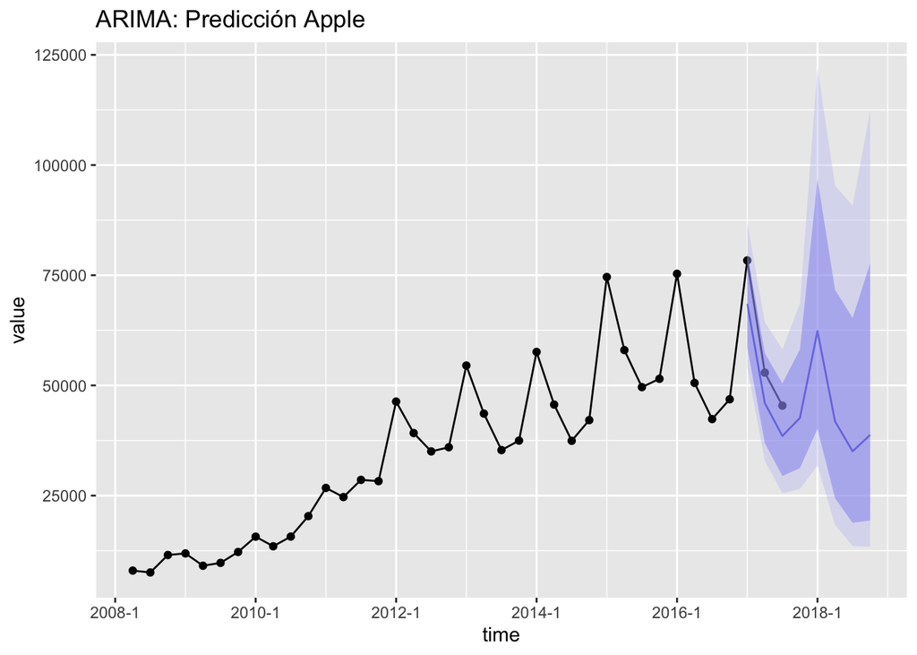

Para poder comparar entre la estimación de ventas del modelo ARIMA y las ventas reales podemos observar la siguiente matriz:

```
##          [,1]  [,2]
## [1,] 68524.50 78351
## [2,] 45993.21 52896
## [3,] 38534.34 45408
```

Tanto por la matriz, como por el gráfico, podemos ver que la predicción está por debajo de las ventas actuales.

Para estudiar la precisión del modelo se debe atender a los errores mostrados a continuación:

```
##          ME        RMSE         MAE         MPE        MAPE        ACF1
## 13573.94444 14080.82042 13573.94444    27.19383    27.19383    -0.50000
##   Theil's U
##     1.31276
```

## Conclusión

Para comparar entre modelos, observamos los errores, como se ha comentado anteriormente. Atendiendo al RMSE o al MAPE podemos ver cómo es mejor el modelo ets, ya que su error es menor.